# HW2

### Homework 3 (due on Friday 9/13 at 11:59 pm CST)

Submission instructions: Submit .ipynb and .html(or.pdf) files in canvas just like you did for HW1. Write your full name in the solutions.

Data set: We will work on a titanic data set in this homework. To know more about Titanic ship, story and the tragedy read this https://www.britannica.com/topic/Titanic

Variables used in this data set

survival - Survival (0 = No; 1 = Yes)

class - Passenger Class (1 = 1st; 2 = 2nd; 3 = 3rd)

name - Name

sex - Sex

age - Age

sibsp - Number of Siblings/Spouses Aboard

parch - Number of Parents/Children Aboard

ticket - Ticket Number

fare - Fare passenger paid in pounds.

cabin - Cabin number

embarked - Where passenger boarded the ship (C = Cherbourg; Q = Queenstown; S = Southampton)

boat - Lifeboat (if survived)

body - Body number (if did not survive and body was recovered)

home.dest - Where passenger is going.

Import pandas as pd and load the titanic data and name it as titanic.

## Problem 1.

We won't be using columns sibsp, parch, ticket, boat and body. Remove these columns and create a new data set containing only the columns pclass, survived, name, sex, age, fare, embarked and home.dest. Please follow the code and instructions in Lab 1 to get help on this. (20 points)

```python
import pandas as pd
df = pd.read_csv('titanic.csv')

df = df.drop("sibsp", axis = 1)
df = df.drop("parch", axis = 1)
df = df.drop("ticket", axis = 1)
df = df.drop("boat", axis = 1)
df = df.drop("body", axis = 1)

df.head()
```

|  | pclass | survived | name | sex | age | fare | cabin | embarked | home.dest |
| --- | --- | --- | --- | --- | --- | --- | --- | --- | --- |
| 0 | 1.0 | 1.0 | Allen, Miss. Elisabeth Walton | female | 29.0000 | 211.3375 | B5 | S | St Louis, MO |
| 1 | 1.0 | 1.0 | Allison, Master. Hudson Trevor | male | 0.9167 | 151.5500 | C22 C26 | S | Montreal, PQ / Chesterville, ON |
| 2 | 1.0 | 0.0 | Allison, Miss. Helen Loraine | female | 2.0000 | 151.5500 | C22 C26 | S | Montreal, PQ / Chesterville, ON |
| 3 | 1.0 | 0.0 | Allison, Mr. Hudson Joshua Creighton | male | 30.0000 | 151.5500 | C22 C26 | S | Montreal, PQ / Chesterville, ON |
| 4 | 1.0 | 0.0 | Allison, Mrs. Hudson J C (Bessie Waldo Daniels) | female | 25.0000 | 151.5500 | C22 C26 | S | Montreal, PQ / Chesterville, ON |

### Problem 2.

count() and value_count() are important functions in pandas that will help us count entries and labels. Read more boaut these here https://pandas.pydata.org/pandas-docs/version/0.23/generated/pandas.DataFrame.count.html and here https://stackoverflow.com/questions/35523635/extract-values-in-pandas-value-counts For example: If I use the code df.sex.vaue_counts(), I get number of male and female in the column sex. (20 points)

```python
import pandas as pd
df = pd.read_csv('titanic.csv')
df.sex.value_counts()
```

```
male      843
female    466
Name: sex, dtype: int64
```

Do the following.

2(a) Use df.count() and explain the output. Why are the numbers not same for all the variables?

2(b) Use df.columnname.value_counts() to answer : How many people survived the tragedy? How many were riding the first class? How many did not have cabins?

```python
df.count()
```

```
pclass       1309
survived     1309
name         1309
sex          1309
age          1046
sibsp        1309
parch        1309
ticket       1309
fare         1308
cabin         295
embarked     1307
boat          486
body          121
home.dest     745
dtype: int64
```

the output tells us the number of entries in each column. The numbers are not the same because we are missing data points for some columns. One reason for this could be that it is harder to track certain data such as cabin number or home destination than others like name, age or sex.

```python
df.survived.value_counts()
```

```
0.0    809
1.0    500
Name: survived, dtype: int64
```

based on the data, only 500 survived

```python
df.pclass.value_counts()
```

```
3.0    709
1.0    323
2.0    277
Name: pclass, dtype: int64
```

323 passengers were riding first class

```python
df.cabin.value_counts()
```

```
C23 C25 C27        6
B57 B59 B63 B66    5
G6                 5
B96 B98            4
D                  4
F33                4
F4                 4
C22 C26            4
F2                 4
C78                4
A34                3
E34                3
C101               3
B58 B60            3
B51 B53 B55        3
E101               3
C32                2
F G73              2
C89                2
E44                2
D19                2
C31                2
D33                2
B18                2
B5                 2
E33                2
C106               2
C83                2
C123               2
C6                 2
                  ..
B82 B84            1
B39                1
B79                1
D46                1
F E46              1
A20                1
B94                1
B4                 1
B61                1
D22                1
C70                1
A7                 1
F E57              1
A6                 1
C128               1
D48                1
C28                1
D43                1
T                  1
C110               1
D38                1
A36                1
F                  1
B3                 1
B11                1
C130               1
C82                1
A9                 1
D11                1
B80                1
Name: cabin, Length: 186, dtype: int64
```

there are only 186 known cabins and roughly 300 cabin assignments are knwon, so around 1000 passengers didn't have cabins

### Problem 3

Use the code df.plot(kind ='scatter', x= 'age', y= 'fare') to make a scatter plot of age and fare with age in x axis and fare in y axis. You will see 3 dots on the top of the graph. Explain what can cause those points to be way on the top? ( 20 points)

### Problem 4

Use the code df.pclass.value_counts().plot(kind='bar') to plot a bar chart of the column pclass. Do the same for the columns survived, sex and embarked. Make some comments on these graphs. (20 points).

### Problem 5

Use the code df.groupby('sex').age.plot(kind='kde'). Learn more about groupby function here https://www.geeksforgeeks.org/python-pandas-dataframe-groupby/. Explain this graph with details on what is plotted, what is it showing, why do we have two graphs and why there are spikes in the middle? (20 points)

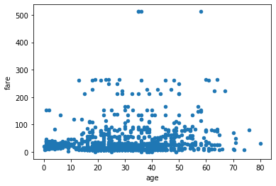

```python
df.plot(kind ='scatter', x= 'age', y= 'fare')
```

These points are outliers because their fare was significantly higher than the rest of the passengers'. A possible reason for this could be they were riding on an exclusive first class that had more benefits than the rest of first class, or maybe they needed special care/assistance which could lead to a higher ticker fare as well.

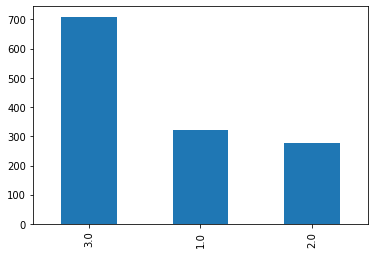

```python
df.pclass.value_counts().plot(kind='bar')
```

based on this graph, we can see that the majority of passengers took 3rd class, while the amount of passengers in 1st and 2nd class were around the same

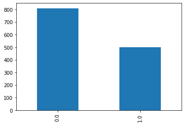

```python
df.survived.value_counts().plot(kind='bar')
```

based on this graph, we can see that more than half the passengers didn't survive the incident

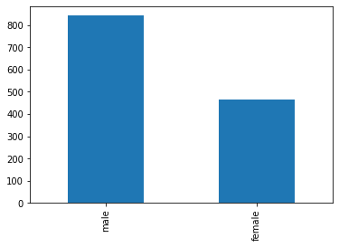

```python
df.sex.value_counts().plot(kind='bar')
```

based on this graph, we can see that the majority of passengers were male

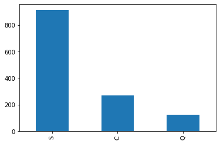

```python
df.embarked.value_counts().plot(kind='bar')
```

Based on this graph, we can see that the majority of passengers embarked from Southampton

```
sex
female    AxesSubplot(0.125,0.125;0.775x0.755)
male      AxesSubplot(0.125,0.125;0.775x0.755)
Name: age, dtype: object
```

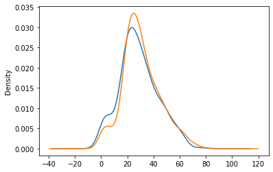

```python
df.groupby('sex').age.plot(kind='kde')
```

This graph plots two different bell curves of the density of passengers of each sex based on their age. Even though there are significantly more males in the data than females, that doesn't play a part in this graph because the density is relative. There are spikes in the middle of the graphs because the majority of passengers, both male and female, were between the ages of 10 and 40, henceforth causing a higher density in those areas on the graph.